# Obrtanje_gradijenta

## Sadržaj ⮭

1. Priprema podataka
2. Tradicionalni model
3. Obrtanje gradijenta
4. Evaluacija modela

## 1. Priprema podataka ⮭

Razmatrani skup podataka može se preuzeti [ovde](https://www.cs.jhu.edu/~mdredze/datasets/sentiment/processed_acl.tar.gz) i sadrži veliki broj recenzija sa sajta Amazon. Recenzije su pretprocesirane i date u $n$-gramskoj formi (vreća unigrama i bigrama), označene kao pozitivne ili negativne (balansirane su po tom kriterijumu), kao i podeljene po domenu, odnosno vrsti proizvoda na koji se odnose. U nastavku je data klasa koja predstavlja jednu recenziju, čuvajući njene $n$-grame (tekst), oznaku (polaritet) i domen (vrsta proizvoda).

```python
# Klasa koja predstavlja jednu recenziju
class Recenzija:
    # Konstrukcija na osnovu učitane linije i domena
    def __init__(self, linija, dom):
        # Podela linije na reči
        linija = linija.strip().split()

        # Rečnik recenzije kao skup n-grama sa brojem pojavljivanja
        recnik = [(r[:r.rfind(':')], int(r[r.rfind(':')+1:])) for r in linija[:-1]]

        # Pretvaranje rečnika u niz n-grama
        tekst = [rec for rec, i in recnik for _ in range(i)]

        # Spajanje niza n-grama u nisku (tekst)
        self.tekst = ' '.join(tekst)

        # Čuvanje oznake (polariteta) recenzije
        self.oznaka = int(linija[-1] == '#label#:negative')

        # Čuvanje domena (vrste) proizvoda
        self.dom = dom
```

Pretpostavka je da unutar svakog pojedinačnog domena može postojati izvor pristrasnosti. Primera radi, korisnici mogu na specifičan način izražavati (ne)zadovoljstvo prema određenom tipu proizvoda. Klasifikatore to ne bi trebalo da zanima, već bi idealno bilo da budu u stanju da prepoznaju opšte načine izražavanja (ne)zadovoljstva, nevezano za vrstu proizvoda. Ideja je, dakle, obučiti modele koji ne uzimaju u obzir domen prilikom klasifikacije. Za potrebe ovog eksperimenta, izabrana su dva tipa prozivoda: elektronski i kuhinjski. Konkretno, recenzije elektronskih proizvoda označene su kao izvorni domen, a kuhinjskih kao ciljni. Zamisao je, dakle, pomoću recenzija elektronskih proizvoda naučiti klasifikator koji dobro klasifikuje i recenzije kuhinjskih. U nastavku su ovi podaci učitani. Konkretno, za svaki domen postoje tri datoteke: `positive.review` sa pozitivnim recenzijama, `negative.review` sa negativnim utiscima i `unlabeled.review` sa ocenama koje služe za proveru modela. Tako nema potrebe za dodatnom podelom na skupove za trening (obuku) i test (proveru).

```python
# Dodavanje sadržaja datoteke u podatake
def dodaj(datoteka, tip):
    with open(datoteka) as f:
        return [Recenzija(l, tip) for l in f.readlines()]

# Učitavanje datoteka odabranog domena
def učitaj(train, test, domen, tip):
    # Dodavanje pozitivnih recenzija
    train.extend(dodaj(f'podaci/{domen}/positive.review', tip))

    # Dodavanje negativnih recenzija
    train.extend(dodaj(f'podaci/{domen}/negative.review', tip))

    # Dodavanje test recenzija
    test.extend(dodaj(f'podaci/{domen}/unlabeled.review', tip))
```

```python
# Inicijalizacija skupova za obuku i proveru
train, test = [], []

# Izvorni domen su elektronski proizvodi
učitaj(train, test, 'electronics', True)

# Ciljni domen su kuhinjski proizvodi
učitaj(train, test, 'kitchen', False)
```

Dobijene tekstualne podatke još treba vektorizovati. Kako je već naglašeno, recenzije su izvorno date u $n$-gramskoj formi. Ipak, učitane su u napisanu klasu, pa je iz nje neophodno izvući sve korisne podatke, kao što je rečnik trening skupa. Odabira se veliki rečnik, ali se zadržavaju samo najčešći $n$-grami.

```python
# Modul za vektorizaciju
from sklearn.feature_extraction.text import CountVectorizer

# Veliki rečnik n-grama
n = 5000

# Inicijalizacija vektorizatora
vektorizator = CountVectorizer(max_features=n, binary=True)

# Obučavanje vektorizatora
_ = vektorizator.fit([t.tekst for t in train])
```

Sada je moguće izdvojiti sve korisne podatke. Konkretno, izdvajaju se glavni podaci sa svojstvima (binarni vektori koji predstavljaju vreće reči), oznake (binarni vektor koji predstavlja polaritet recenzije) i domeni (binarni vektor koji predstavlja tip domena). Jednako se postupa sa skupovima za trening i test.

```python
# Modul za rad sa tabelama
import pandas as pd

# Priprema podataka za dalji rad
def pripremi(podaci, vektorizator):
    # Vreća reči prosleđenog skupa
    x = vektorizator.transform([t.tekst for t in podaci])
    x = pd.DataFrame(x.todense(), columns=vektorizator.get_feature_names_out())

    # Oznake i domen prosleđenog skupa
    y = pd.Series([t.oznaka for t in podaci])
    z = pd.Series([t.dom for t in podaci])

    # Vraćanje pripremljenih podataka
    return x, y, z
```

```python
# Priprema skupa za obuku
x_train, y_train, z_train = pripremi(train, vektorizator)

# Priprema skupa za proveru
x_test, y_test, z_test = pripremi(test, vektorizator)
```

## 2. Tradicionalni model ⮭

Prvo je formiran tradicionalni model, koji ne uzima u obzir domen instance. Konkretno, ovaj model predstavlja jednostavnu neuronsku mrežu sa samo jednim potpuno povezanim skrivenim slojem (enkoderom), čija je aktivacija linearna ispravljačka jedinica (*ReLU*), dok je na izlazu iz mreže sigmoidna aktivacija. Prvo je napisana bazna klasa, koja će biti korišćena i u nastavku, a zatim konkretna klasa, koja predstavlja opisani tradicionalni neuronski klasifikator.

```python
# Modul za klasični rad sa mrežama
import torch, torch.nn as nn

# Osnovna klasa za sve dalje modele
class Suparnik(nn.Module):
    # Konstrukcija na osnovu arhitekturalnih parametara
    def __init__(self, ulaz=n, skriveni=4, klase=1, seme=0):
        # Inicijalizacija PyTorch modula
        super().__init__()

        # Fiksiranje izvora pseudoslučajnosti
        torch.manual_seed(seme)

        # Linearna ispravljačka aktivacija
        self.relu = nn.ReLU()

        # Sigmoidna aktivacija
        self.sigm = nn.Sigmoid()

        # Potpuno povezani skriveni sloj
        self.enc = nn.Linear(ulaz, skriveni, bias=False)

        # Potpuno povezani izlazni sloj
        self.klas = nn.Linear(skriveni, klase, bias=False)
```

```python
# Tradicionalni klasifikator
class Tradicionalni(Suparnik):
    # Konstrukcija bazne klase
    def __init__(self, ulaz=n, skriveni=4, klase=1, seme=0):
        super().__init__(n, skriveni, klase, seme)

    # Funkcija za propagaciju unapred
    def forward(self, x):
        # Enkodiranje ulaza
        x = self.enc(x)

        # Ispravljačka aktivacija
        x = self.relu(x)

        # Dekodiranje izlaza
        y = self.klas(x)

        # Sigmoidna aktivacija
        y = self.sigm(y)

        # Vraćanje rezultata
        return y
```

```python
# Modul za sumarizaciju modela
from torchinfo import summary

# Sumarizacija modela nad jednom instancom
display(summary(Tradicionalni(), col_names=('input_size', 'output_size',
        'num_params', 'mult_adds'), col_width=21, input_size=(1, n)))
```

```
============================================================================================================================
Layer (type:depth-idx)                   Input Shape           Output Shape          Param #               Mult-Adds
============================================================================================================================
Tradicionalni                            [1, 5000]             [1, 1]                --                    --
├─Linear: 1-1                            [1, 5000]             [1, 4]                20,000                20,000
├─ReLU: 1-2                              [1, 4]                [1, 4]                --                    --
├─Linear: 1-3                            [1, 4]                [1, 1]                4                     4
├─Sigmoid: 1-4                           [1, 1]                [1, 1]                --                    --
============================================================================================================================
Total params: 20,004
Trainable params: 20,004
Non-trainable params: 0
Total mult-adds (M): 0.02
============================================================================================================================
Input size (MB): 0.02
Forward/backward pass size (MB): 0.00
Params size (MB): 0.08
Estimated Total Size (MB): 0.10
============================================================================================================================
```

Kako je za rad sa neuronskim mrežama korišćena biblioteka *PyTorch*, neophodno je ručno napisati funkciju za obučavanje modela. Koristi se optimizator *Adam*, sa nešto većim brojem epoha. Napisana je i pomoćna funkcija za prevod podataka u odgovarajući oblik, što su posebni *PyTorch* tenzori.

```python
# Modul za rad sa nizovima
import numpy as np

# Modul za minimizaciju greške
from torch.optim import Adam

# Modul za grafičko praćenje obuke
from matplotlib import pyplot as plt
from matplotlib.ticker import MaxNLocator

# Odabrani broj epoha
epoha = 650

# Prevođenje numpy niza u torch tenzor
def tenzor_od_niza(niz):
    return torch.from_numpy(niz.astype(np.float32))
```

Kako podataka nema previše, ne dele se na pakete, već se ceo skup za obuku izjedna provlači kroz neuronsku mrežu. Za potrebe ažuriranja parametara mreže na kraju epohe, kao funkcija greške koristi se binarna unakrsna entropija. Na kraju obuke, prikazuje se grafik toka greške kroz vreme (epohe).

```python
# Obučavanje tradicionalne mreže
def obuči(model, x_train, y_train, epoha=epoha):
    # Pravljenje optimizatora nad mrežom
    if not hasattr(model, 'adam'):
        model.adam = Adam(model.parameters())

    # Binarna unakrsna entropija kao greška
    if not hasattr(model, 'bce'):
        model.bce = nn.BCELoss()

    # Postavljanje moda za obuku
    model.train()

    # Niz grešaka po epohama
    greške = []

    # Iteracija kroz epohe
    for i in range(epoha):
        # Dohvatanje podataka kao nizova
        x = x_train.to_numpy()
        y = y_train.to_numpy()

        # Dohvatanje podataka kao tenzora
        x = tenzor_od_niza(x)
        y = tenzor_od_niza(y).unsqueeze(1)

        # Propagacija unapred kroz model
        y_pred = model(x)

        # Izračunavanje greške predviđanja
        greška = model.bce(y_pred, y)

        # Dodavanje greške u niz po epohama
        greške.append(greška.item())

        # Osvežavanje stanja optimizatora
        model.adam.zero_grad()

        # Propagacija greške unazad
        greška.backward()

        # Korak optimizatora
        model.adam.step()

    # Postavljanje celobrojnih osa grafika
    plt.axes().xaxis.set_major_locator(MaxNLocator(integer=True))

    # Crtanje toka greške kroz vreme (epohe)
    plt.plot(range(1, epoha+1), greške)

    # Vraćanje modela
    return model

# Dodavanje nove funkcije klasi
Tradicionalni.obuči = obuči
```

Sada je moguće obučiti tradicionalni model. Konkretno, obučavaju se tri modela: prvi koji uči samo na recenzijama elektronskih uređaja (izvorni domen), drugi koji uči samo na recenzijama kuhinjskih uređaja (ciljni domen) i treći koji uči na svim recenzijama iz skupa za obuku, dakle na obe vrste uređaja.

```python
# Instanciranje i obuka modela
def model(klasa, *args):
    return klasa().obuči(*args)
```

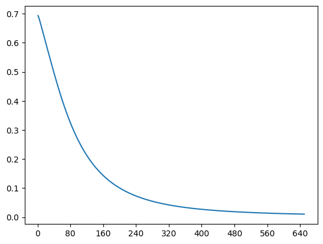

```python
# Tradicionalni model nad elektronskim uređajima
trad_elek = model(Tradicionalni, x_train[z_train], y_train[z_train])
```

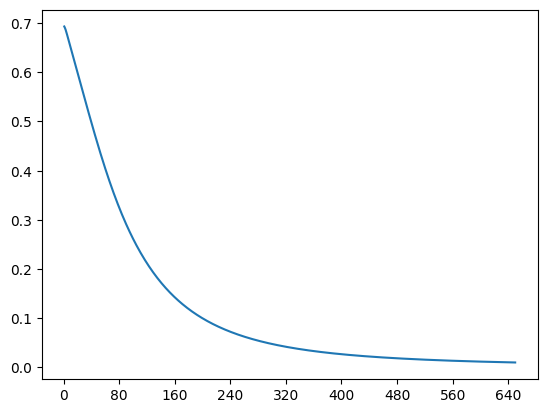

```python
# Tradicionalni model nad kuhinjskim uređajima
trad_kuh = model(Tradicionalni, x_train[~z_train], y_train[~z_train])
```

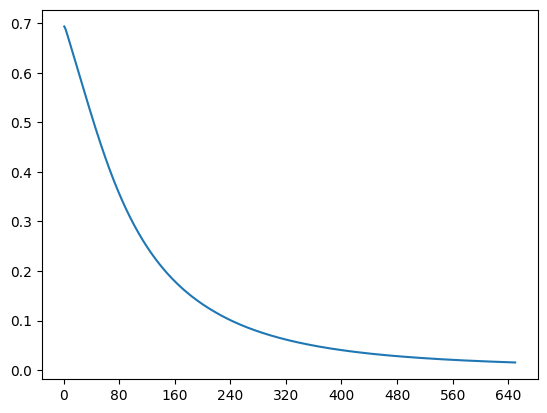

```python
# Tradicionalni model nad svim uređajima
trad_svi = model(Tradicionalni, x_train, y_train)
```

## 3. Obrtanje gradijenta ⮭

Detalji o obrtanju gradijenta kao ideji mogu se videti [ovde](https://arxiv.org/abs/1409.7495), dok se njegova primena u klasifikaciji teksta može videti [ovde](https://arxiv.org/abs/2002.10937). Ukratko, ova tehnika se odlikuje grananjem neuronske mreže, pri čemu postoji zajednički deo, koji se zatim deli na dve grane – glavnu i suparničku. Glavna grana rešava konkretan problem (klasifikacija), dok suparnička otkriva eventualni izvor pristrasnosti (domen). Prilikom ažuriranja parametara modela, zasnovanog na gradijentnoj minimizaciji greške, gradijent se obrće (negira) na zajedničkom delu suparničke grane. Ovime se efektivno otklanja izvor pristrasnosti, pa je rezultujući model (predstavǉen glavnom granom) robusniji. U nastavku je implementirana funkcija koja obrće gradijent, kao i opisani model sa grananjem za potrebe rada sa recenzijama.

```python
# Modul za rad sa funkcijama
from torch.autograd import Function

# Funkcija za obrtanje gradijenta
class Obrtanje(Function):
    # Propagacija unapred je neizmenjena
    @staticmethod
    def forward(ctx, x):
        return x

    # Propagacija unazad negira gradijent
    @staticmethod
    def backward(ctx, grad):
        return -grad

# Čuvanje funkcije za lakšu upotrebu
obrni = Obrtanje.apply
```

```python
# Domenski klasifikator
class Domenski(Suparnik):
    # Konstrukcija bazne klase
    def __init__(self, ulaz=n, skriveni=4, klase=1, seme=0):
        super().__init__(n, skriveni, klase, seme)

        # Potpuno povezani domenski sloj
        self.dom = nn.Linear(skriveni, klase, bias=False)

    # Funkcija za propagaciju unapred
    def forward(self, x):
        # Enkodiranje ulaza
        x = self.enc(x)

        # Ispravljačka aktivacija
        x = self.relu(x)

        # Dekodiranje izlaza
        y = self.klas(x)

        # Sigmoidna aktivacija
        y = self.sigm(y)

        # Obrtanje gradijenta
        z = obrni(x)

        # Dekodiranje domena
        z = self.dom(z)

        # Sigmoidna aktivacija
        z = self.sigm(z)

        # Vraćanje rezultata
        return y, z
```

```python
# Sumarizacija modela nad jednom instancom
display(summary(Domenski(), col_names=('input_size', 'output_size',
        'num_params', 'mult_adds'), col_width=21, input_size=(1, n)))
```

```
============================================================================================================================
Layer (type:depth-idx)                   Input Shape           Output Shape          Param #               Mult-Adds
============================================================================================================================
Domenski                                 [1, 5000]             [1, 1]                --                    --
├─Linear: 1-1                            [1, 5000]             [1, 4]                20,000                20,000
├─ReLU: 1-2                              [1, 4]                [1, 4]                --                    --
├─Linear: 1-3                            [1, 4]                [1, 1]                4                     4
├─Sigmoid: 1-4                           [1, 1]                [1, 1]                --                    --
├─Linear: 1-5                            [1, 4]                [1, 1]                4                     4
├─Sigmoid: 1-6                           [1, 1]                [1, 1]                --                    --
============================================================================================================================
Total params: 20,008
Trainable params: 20,008
Non-trainable params: 0
Total mult-adds (M): 0.02
============================================================================================================================
Input size (MB): 0.02
Forward/backward pass size (MB): 0.00
Params size (MB): 0.08
Estimated Total Size (MB): 0.10
============================================================================================================================
```

```python
# Obučavanje suparničke mreže
def obuči(model, x_train, y_train, z_train, svi, epoha=epoha):
    # Pravljenje optimizatora nad mrežom
    if not hasattr(model, 'adam'):
        model.adam = Adam(model.parameters())

    # Binarna unakrsna entropija kao greška
    if not hasattr(model, 'bce'):
        model.bce = nn.BCELoss()

    # Postavljanje moda za obuku
    model.train()

    # Niz grešaka po epohama
    gklas = []
    gdom = []
    greške = []

    # Iteracija kroz epohe
    for i in range(1, epoha+1):
        # Dohvatanje podataka kao nizova
        x = x_train.to_numpy()
        y = y_train.to_numpy()
        z = z_train.to_numpy()

        # Dohvatanje podataka kao tenzora
        x = tenzor_od_niza(x)
        y = tenzor_od_niza(y).unsqueeze(1)
        z = tenzor_od_niza(z).unsqueeze(1)

        # Propagacija unapred kroz model
        try:
            y_pred, z_pred = model(x, y)
        except:
            y_pred, z_pred = model(x)

        # Eventualno izdvajanje izvornog domena
        if not svi:
            neki = torch.tensor(np.flatnonzero(z_train))
            y_pred = torch.index_select(y_pred, 0, neki)
            y = torch.index_select(y, 0, neki)

        # Izračunavanje greške predviđanja oznake
        g1 = model.bce(y_pred, y)
        gklas.append(g1.item())

        # Izračunavanje greške predviđanja domena
        g2 = model.bce(z_pred, z)
        gdom.append(g2.item())

        # Zbirna greška predviđanja
        g = g1 + g2
        greške.append(g.item())

        # Osvežavanje stanja optimizatora
        model.adam.zero_grad()

        # Propagacija greške unazad
        g.backward()

        # Korak optimizatora
        model.adam.step()

    # Postavljanje celobrojnih osa grafika
    plt.axes().xaxis.set_major_locator(MaxNLocator(integer=True))

    # Crtanje toka grešaka kroz vreme (epohe)
    plt.plot(range(1, epoha+1), gklas, label='class')
    plt.plot(range(1, epoha+1), gdom, label='advers')
    plt.plot(range(1, epoha+1), greške, label='total')

    # Ucrtavanje legende grafika
    plt.legend()

    # Vraćanje modela
    return model

# Dodavanje nove funkcije klasi
Suparnik.obuči = obuči
```

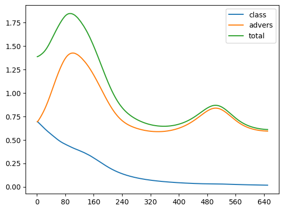

```python
# Domenski model nad elektronskim uređajima
dom_neki = model(Domenski, x_train, y_train, z_train, False)
```

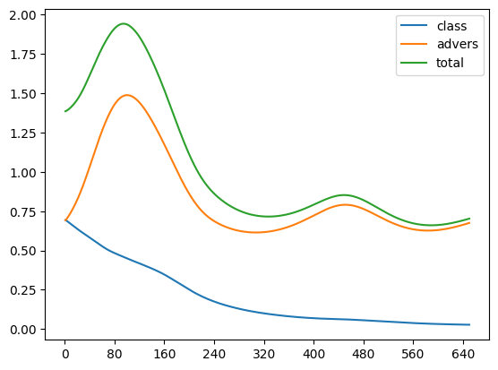

```python
# Domenski model nad svim uređajima
dom_svi = model(Domenski, x_train, y_train, z_train, True)
```

Alternativno, problemu se može pristupiti na drugi način, čiji se detalji mogu videti [ovde](https://arxiv.org/abs/1801.07593). U ovom pristupu, nema eksplicitnog grananja modela, već se suparnička grana nadovezuje na rezultat sigmoidno dekodiranog izlaza klasifikatora. Konkretno, formira se vektor od tri vrednosti, koje na različite načine oslikavaju korektnost predviđanja, a zatim se ta reprezentacija dekodira kako bi se predvideo domen. Očigledno, na ovaj način nije moguće predvideti domen neobeleženih instanci, mada to i nije neophodno. S druge strane, obuka je stabilna. Ovaj pristup je popularan u obradi prirodnih jezika, budući da pruža jednakost mogućnosti, koja je neophodna u izgradnji nepristrasnih jezičkih modela. I ovaj model se, potpuno isto kao i prethodni, obučava na dva načina.

```python
# Nepristrasni klasifikator
class Nepristrastan(Suparnik):
    # Konstrukcija bazne klase:
    def __init__(self, ulaz=n, skriveni=4, klase=1, seme=0):
        super().__init__(n, skriveni, klase, seme)

        # Skala sigurnosti klasifikatora
        self.c = nn.Linear(klase, klase, bias=False)

        # Potpuno povezani domenski sloj
        self.deb = nn.Linear(3, klase)

    # Funkcija za propagaciju unapred
    def forward(self, x, yt=None):
        # Enkodiranje ulaza
        x = self.enc(x)

        # Ispravljačka aktivacija
        x = self.relu(x)

        # Dekodiranje izlaza
        y = self.klas(x)

        # Skalirana sigmoidna aktivacija
        y = self.sigm(self.c(y))

        # Kraj ukoliko nije poznata klasa
        if yt is None:
            return y

        # Obrtanje gradijenta
        z = obrni(y)

        # Međureprezentacija predviđanja
        z = torch.cat([z, z * yt, z * (1 - yt)], dim=1)

        # Dekodiranje domena
        z = self.deb(z)

        # Sigmoidna aktivacija
        z = self.sigm(z)

        # Vraćanje rezultata
        return y, z
```

```python
# Sumarizacija modela nad jednom instancom
display(summary(Nepristrastan(), col_names=('input_size', 'output_size',
        'num_params', 'mult_adds'), col_width=21, input_size=[(1, n), (1,)]))
```

```
============================================================================================================================
Layer (type:depth-idx)                   Input Shape           Output Shape          Param #               Mult-Adds
============================================================================================================================
Nepristrastan                            [1, 5000]             [1, 1]                --                    --
├─Linear: 1-1                            [1, 5000]             [1, 4]                20,000                20,000
├─ReLU: 1-2                              [1, 4]                [1, 4]                --                    --
├─Linear: 1-3                            [1, 4]                [1, 1]                4                     4
├─Linear: 1-4                            [1, 1]                [1, 1]                1                     1
├─Sigmoid: 1-5                           [1, 1]                [1, 1]                --                    --
├─Linear: 1-6                            [1, 3]                [1, 1]                4                     4
├─Sigmoid: 1-7                           [1, 1]                [1, 1]                --                    --
============================================================================================================================
Total params: 20,009
Trainable params: 20,009
Non-trainable params: 0
Total mult-adds (M): 0.02
============================================================================================================================
Input size (MB): 0.02
Forward/backward pass size (MB): 0.00
Params size (MB): 0.08
Estimated Total Size (MB): 0.10
============================================================================================================================
```

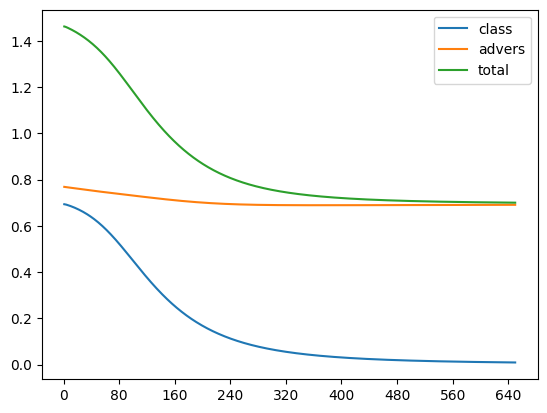

```python
# Nepristrasni model nad elektronskim uređajima
nepristrastan_neki = model(Nepristrastan, x_train, y_train, z_train, False)
```

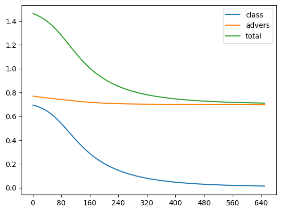

```python
# Nepristrasni model nad svim uređajima
nepristrastan_svi = model(Nepristrastan, x_train, y_train, z_train, True)
```

## 4. Evaluacija modela ⮭

Za kraj, modeli se evaluiraju, kako bi se mogli uporediti. Prvo je implementiran metod za sprovođenje klasifikacije, a zatim i metod za evaluaciju. Kako se razmatra problem binarne klasifikacije, drugi metod prikazuje matricu konfuzije, koja razdvaja tačno klasifikovane recenzije od netačno kategorizovanih. Matrica je bolja utoliko što više odgovara dijagonalnoj. Prikazana je i procentualna mera kvaliteta $F_1$, koja je direktno srazmerna kvalitetu klasifikacije.

```python
# Klasifikacija odabranim modelom
def predvidi(model, x_test):
    # Postavljanje moda za proveru
    model.eval()

    # Zanemarivanje gradijenata
    with torch.no_grad():
        # Dohvatanje podataka kao nizova
        x = x_test.to_numpy()

        # Dohvatanje podataka kao tenzora
        x = tenzor_od_niza(x)

        # Propagacija unapred kroz model
        y_pred = model(x)

        # Dohvatanje klase ako nije jedina
        if isinstance(y_pred, tuple):
            y_pred = y_pred[0]

        # Zaokruživanje predviđanja
        return y_pred.numpy()[:, -1] > .5

# Dodavanje nove funkcije klasi
Suparnik.predvidi = predvidi
```

```python
# Modul za rad sa F1 merom kvaliteta
from sklearn.metrics import f1_score

# Modul za rad sa matricama konfuzije
from sklearn.metrics import confusion_matrix, ConfusionMatrixDisplay

# Pravljenje jedne matrice konfuzije
def matrica(model, x_test, y_test, domen, ax):
    # Predviđanje modela na skupu za proveru
    y_pred = model.predvidi(x_test)

    # Matrica konfuzije na osnovu predviđanja
    mat = confusion_matrix(y_test, y_pred)

    # Crtanje izračunate matrice konfuzije
    ConfusionMatrixDisplay(mat).plot(cmap='binary', colorbar=False, ax=ax)

    # F1 mera kvaliteta na osnovu predviđanja
    f1 = f1_score(y_test, y_pred)

    # Upisivanje domena i mere kvaliteta
    ax.set_title(f'{domen} [F$_1$ = {f1:.2%}]')

# Funkcija za crtanje matrica konfuzije
def konfuzija(model, x_test, y_test, z_test):
    # Podela grafika na dva dela
    fig, axs = plt.subplots(1, 2, figsize=(8, 4), sharex=True, sharey=True)

    # Matrica konfuzije izvornog domena
    matrica(model, x_test[z_test], y_test[z_test], 'Elektronika', axs[0])

    # Matrica konfuzije ciljnog domena
    matrica(model, x_test[~z_test], y_test[~z_test], 'Kuhinja', axs[1])

# Dodavanje nove funkcije klasi
Suparnik.konf = konfuzija
```

Kao osnovni, prvo se evaluira tradicionalni model koji je obučen nad svim uređajima. On pokazuje zavidan kvalitet oko $86\%$ na oba domena. Ekvivalentan nepristrasni model daje slične rezultate. Razgranati domenski model, međutim, donosi osetno poboljšanje na oba domena, pa je sada kvalitet oko $88\%$. Ovo znači da ublažavanje pristrasnosti obrtanjem gradijenta ima regularizacionu ulogu, budući da pospešuje generalizaciju modela i smanjuje preprilagođavanje.

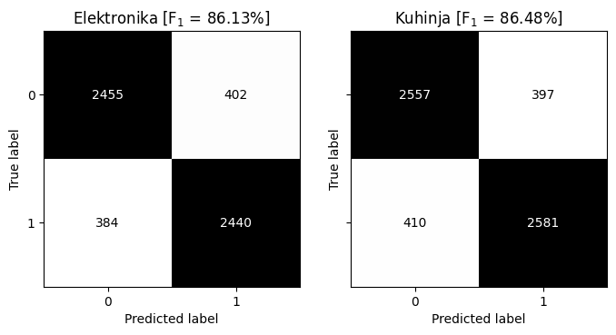

```python
# Evaluacija tradicionalnog modela obučenog nad svim uređajima
trad_svi.konf(x_test, y_test, z_test)
```

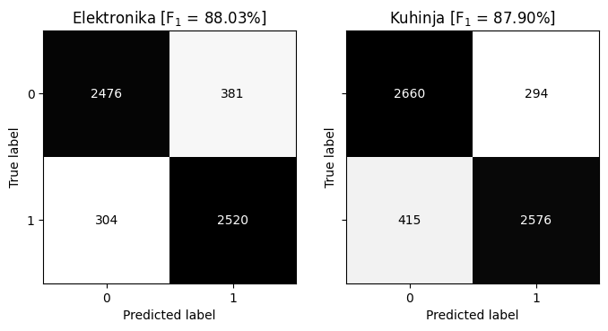

```python
# Evaluacija domenskog modela obučenog nad svim uređajima
dom_svi.konf(x_test, y_test, z_test)
```

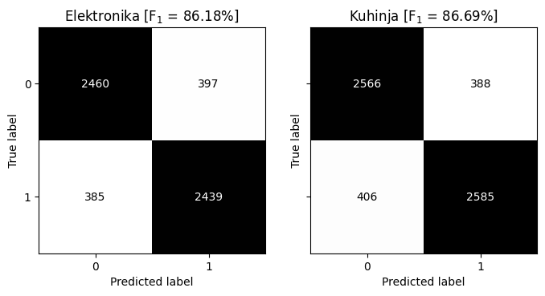

```python
# Evaluacija nepristrasnog modela obučenog nad svim uređajima
nepristrastan_svi.konf(x_test, y_test, z_test)
```

Kada su u pitanju tradicionalni modeli obučeni nad podacima koji dolaze samo iz jednog domena, primetno je očekivano lošije ponašanje na podacima iz drugog domena. Tako je kvalitet modela na izvornom domenu oko $85-86\%$, slično kao kod punog modela, dok je na ciljnom $82-83\%$, što je pad.

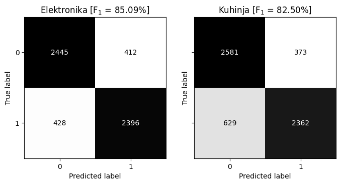

```python
# Evaluacija tradicionalnog modela obučenog nad elektronskim uređajima
trad_elek.konf(x_test, y_test, z_test)
```

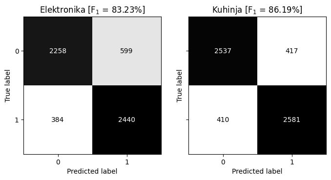

```python
# Evaluacija tradicionalnog modela obučenog nad kuhinjskim uređajima
trad_kuh.konf(x_test, y_test, z_test)
```

Problem nestaje upotrebom suparničkog učenja obrtanjem gradijenta, pa tako razlika u rezultatima postaje zanemariljiva i svodi se na početnih oko $86\%$. Pritom je primetno da je manja razlika kod nepristrasnog modela, što je i očekivano, budući da je za njega u literaturi pokazano da pruža jednakost mogućnosti: konceptualno garantuje približno jednake rezultate, iako ne nužno odlične. I to je, naravno, svojevrsna specifična domenska regularizacija.

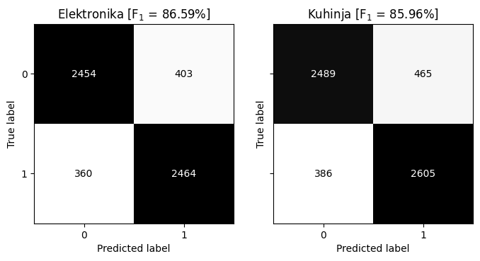

```python
# Evaluacija domenskog modela obučenog nad nekim uređajima
dom_neki.konf(x_test, y_test, z_test)
```

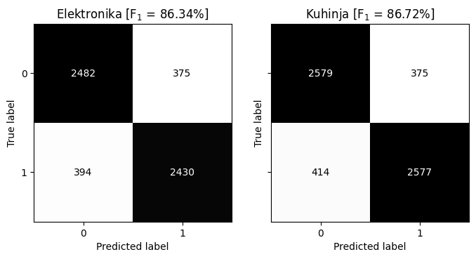

```python
# Evaluacija nepristrasnog modela obučenog nad nekim uređajima
nepristrastan_neki.konf(x_test, y_test, z_test)
```